# Biostat 212A Homework 3

## 2 ISL Exercise 5.4.9 (20pts)

> We will now consider the `Boston` housing data set, from the `ISLR2` library.
> 1. Based on this data set, provide an estimate for the population mean of `medv`. Call this estimate $\hat\mu$.

**Answer:**

```r
mu <- mean(Boston$medv)
mu
```

```
[1] 22.53281
```

> 2. Provide an estimate of the standard error of $\hat\mu$. Interpret this result.

> *Hint: We can compute the standard error of the sample mean by dividing the sample standard deviation by the square root of the number of observations.*

**Answer:**

```r
se <- sd(Boston$medv) / sqrt(length(Boston$medv))
se
```

```
[1] 0.4088611
```

> 3. Now estimate the standard error of $\hat\mu$ using the bootstrap. How does this compare to your answer from (b)?

**Answer:**

```r
set.seed(123)
boot <- boot(Boston$medv, function(v, i) mean(v[i]), 10000)
boot
```

```
ORDINARY NONPARAMETRIC BOOTSTRAP


Call:
boot(data = Boston$medv, statistic = function(v, i) mean(v[i]),
    R = 10000)


Bootstrap Statistics :
    original       bias    std. error
t1* 22.53281 -0.002135435   0.4088195
```

> 4. Based on your bootstrap estimate from (c), provide a 95% confidence interval for the mean of `medv`. Compare it to the results obtained using `t.test(Boston$medv)`.

> *Hint: You can approximate a 95% confidence interval using the formula $[\hat\mu - 2SE(\hat\mu), \hat\mu + 2SE(\hat\mu)].$*

**Answer:**

```r
se_boot <- sd(boot$t)
c(mu - 2 * se_boot, mu + 2 * se_boot)
```

```
[1] 21.71517 23.35045
```

```r
t.test(Boston$medv)$conf.int
```

```
[1] 21.72953 23.33608
attr(,"conf.level")
[1] 0.95
```

The 95% confidence interval using the bootstrap is (21.7152, 23.3505), which is close to the result from `t.test(Boston$medv)` (21.7295, 23.3361).

> 5. Based on this data set, provide an estimate, $\hat\mu_{med}$, for the median value of `medv` in the population.

**Answer:**

```r
median(Boston$medv)
```

```
[1] 21.2
```

> 6. We now would like to estimate the standard error of $\hat\mu_{med}$. Unfortunately, there is no simple formula for computing the standard error of the median. Instead, estimate the standard error of the median using the bootstrap. Comment on your findings.

**Answer:**

```r
set.seed(123)
boot(Boston$medv, function(v, i) median(v[i]), 10000)
```

```
ORDINARY NONPARAMETRIC BOOTSTRAP


Call:
boot(data = Boston$medv, statistic = function(v, i) median(v[i]),
    R = 10000)


Bootstrap Statistics :
    original   bias    std. error
t1*     21.2 -0.01458   0.3773774
```

The estimated standard error of the median is 0.377, which is lower than the standard error of the mean we have calculated before.

> 7. Based on this data set, provide an estimate for the tenth percentile of `medv` in Boston census tracts. Call this quantity $\hat\mu_{0.1}$. (You can use the `quantile()` function.)

**Answer:**

```r
quantile(Boston$medv, 0.1)
```

```
  10%
12.75
```

> 8. Use the bootstrap to estimate the standard error of $\hat\mu_{0.1}$. Comment on your findings.

**Answer:**

```r
set.seed(123)
boot(Boston$medv, function(v, i) quantile(v[i], 0.1), 10000)
```

```
ORDINARY NONPARAMETRIC BOOTSTRAP


Call:
boot(data = Boston$medv, statistic = function(v, i) quantile(v[i],
    0.1), R = 10000)


Bootstrap Statistics :
    original   bias    std. error
t1*    12.75 0.007145   0.5073489
```

Here we have the standard error of the 10th percentile is 0.507, which is higher than the standard error of both the mean and the median we have calculated before.

## 3 Least squares is MLE (10pts)

Show that in the case of linear model with Gaussian errors, maximum likelihood and least squares are the same thing, and $C_p$ and AIC are equivalent.

**Answer:** Consider a linear model:
$$Y = X\beta + \epsilon$$
where $\epsilon \sim N(0, \sigma^2)$.

For Least Squares Estimation (LSE), the minimization function of the sum of squared residuals is:
$$S(\beta) = (Y - X\beta)^\top (Y - X\beta)$$

For Maximum Likelihood Estimation (MLE), the maximization function of the likelihood is:
$$L(\beta, \sigma^2) = \prod_{i=1}^{n} \frac{1}{\sqrt{2\pi\sigma^2}} \exp\left(-\frac{(y_i - x_i^\top\beta)^2}{2\sigma^2}\right)$$
Take the log of the function, then we have:
$$\log L(\beta, \sigma^2) = -\frac{n}{2}\log(2\pi) - \frac{n}{2}\log(\sigma^2) - \frac{1}{2\sigma^2}(Y - X\beta)^\top (Y - X\beta)$$
When maximizing the log-likelihood with respect to $\beta$, ignoring the constant terms, we have:
$$(Y - X\beta)^\top (Y - X\beta)$$
which is exactly the same with the minimization function of LSE. Here we have the same criteria for the MLE and LSE, and they are equivalent for the linear model with Gaussian errors.

For Mallow’s $C_p$, given by:
$$C_p = \frac{1}{n} (\text{RSS} + 2d \hat{\sigma}^2),$$

AIC is given by:
$$\text{AIC} = - 2 \log L + 2d,$$
where $L$ is the maximized value of the likelihood function for the estimated model. Substitute the log-likelihood function, which is:
$$\log(L) = -\frac{n}{2} \log(2\pi\hat{\sigma}^2) - \frac{\text{RSS}}{2\hat{\sigma}^2}$$
We have AIC:
$$\text{AIC} = n \log(2\pi\hat{\sigma}^2) + \frac{\text{RSS}}{\hat{\sigma}^2} + 2d$$

As $n \log(2\pi\hat{\sigma}^2)$ is a constant, we can ignore it. Then we have:
$$\frac{\text{RSS}}{\hat{\sigma}^2} + 2d$$
which can be represented by:
$$\frac{n}{\hat{\sigma}^2}C_p$$

Therefore, we have the same criteria for $C_p$ and AIC in this situation; thus, they are equivalent for the linear model with Gaussian errors.

## 4 ISL Exercise 6.6.1 (10pts)

> We perform best subset, forward stepwise, and backward stepwise selection on a single data set. For each approach, we obtain $p + 1$ models, containing $0, 1, 2, ..., p$ predictors. Explain your answers:
> 1. Which of the three models with $k$ predictors has the smallest *training* RSS?

**Answer:** Best subset will consider the highest number of combinations of predictors, meaning all of possible combinations of $k$ predictors will be considered. Therefore, the best subset will have the smallest training RSS, as the best subset method will also include the combinations in forward stepwise and backward stepwise. However, the results in these three methods will not have a too large difference.

> 2. Which of the three models with $k$ predictors has the smallest *test* RSS?

**Answer:** It cannot be sure that which model has the smallest test RSS since it depends on the trade-off between bias and variance, as well as the overfitting and the underfitting.

> 3. True or False:
>    1. The predictors in the $k$-variable model identified by forward stepwise are a subset of the predictors in the ($k+1$)-variable model identified by forward stepwise selection.

**Answer:** True. Forward stepwise selection will include all predictors added in the previous step with $k$ increasing.

> 2. The predictors in the $k$-variable model identified by backward stepwise are a subset of the predictors in the $(k+1)$-variable model identified by backward stepwise selection.

**Answer:** True. Backward stepwise selection will remove predictors one by one with $k$ decreasing.

> 3. The predictors in the $k$-variable model identified by backward stepwise are a subset of the predictors in the $(k+1)$-variable model identified by forward stepwise selection.

**Answer:** False. Forward and backward stepwise selection may have different combinations of predictors since they have the different algorithms.

> 4. The predictors in the $k$-variable model identified by forward stepwise are a subset of the predictors in the $(k+1)$-variable model identified by backward stepwise selection.

**Answer:** False. The reason is the same as question iii, as it have different algorithms.

> 22. The predictors in the $k$-variable model identified by best subset are a subset of the predictors in the $(k+1)$-variable model identified by best subset selection.

**Answer:** False. The reason is still the same, as different algorithms may result in different combinations.

## 5 ISL Exercise 6.6.3 (10pts)

> Suppose we estimate the regression coefficients in a linear regression model by minimizing:

> $$\sum_{i=1}^n\left(y_i - \beta_0 - \sum_{j=1}^p\beta_jx_{ij}\right)^2
> \textrm{subject to} \sum_{j=1}^p|\beta_j| \le s$$

> for a particular value of $s$. For parts (a) through (e), indicate which of i. through v. is correct. Justify your answer.
> 1. As we increase $s$ from 0, the training RSS will:
>    1. Increase initially, and then eventually start decreasing in an inverted U shape.
>    2. Decrease initially, and then eventually start increasing in a U shape.
>    3. Steadily increase.
>    4. Steadily decrease.
>    5. Remain constant.

**Answer:** iv is correct. With increasing of $s$, the model will be more flexible; thus, training RSS will always decrease steadily.

> 2. Repeat (a) for test RSS.

**Answer:** ii is correct. When the model is more flexible, test RSS will initially decrease since the model fits the data better. However, when it continues, test RSS will increase as overfitting happens.

> 3. Repeat (a) for variance.

**Answer:** iii is correct. As the model will be more flexible when $s$ increases, the variance will increase.

> 4. Repeat (a) for (squared) bias.

**Answer:** iv is correct. As $s$ increases, the model will be more flexible; thus, bias will decrease steadily.

> 5. Repeat (a) for the irreducible error.

**Answer:** v is correct. The irreducible error will not be changed no matter how $s$ changes.

## 6 ISL Exercise 6.6.4 (10pts)

> Suppose we estimate the regression coefficients in a linear regression model by minimizing

> $$\sum_{i=1}^n \left(y_i - \beta_0 - \sum_{j=1}^p\beta_jx_{ij}\right)^2 +
> \lambda\sum_{j=1}^p\beta_j^2$$

> 2. Repeat (a) for test RSS.

**Answer:** ii is correct. When $\lambda$ increases, flexibility of the model will decrease. Therefore, test RSS will firstly decrease as variance decreasing and then increase as bias increasing.

> 3. Repeat (a) for variance.

**Answer:** iv is correct. Increasing of $lambda$ will result in decreasing of flexibility; thus, variance will steadily decrease.

> 4. Repeat (a) for (squared) bias.

**Answer:** iii is correct. Decreasing of flexibility will make squared bias steadily increase.

> 5. Repeat (a) for the irreducible error.

**Answer:** v is correct. The irreducible error is not changeable.

## 7 ISL Exercise 6.6.5 (10pts)

> It is well-known that ridge regression tends to give similar coefficient values to correlated variables, whereas the lasso may give quite different coefficient values to correlated variables. We will now explore this property in a very simple setting.

> Suppose that $n = 2, p = 2, x_{11} = x_{12}, x_{21} = x_{22}$. Furthermore, suppose that $y_1 + y_2 =0$ and $x_{11} + x_{21} = 0$ and $x_{12} + x_{22} = 0$, so that the estimate for the intercept in a least squares, ridge regression, or lasso model is zero: $\hat{\beta}_0 = 0$.
> 1. Write out the ridge regression optimization problem in this setting.

**Answer:** From the problem description, we are actually trying to minimize:

$$\sum_{i=1}^n \left(y_i - \beta_0 - \sum_{j=1}^p\beta_jx_{ij}\right)^2 +
\lambda\sum_{j=1}^p\beta_j^2$$

As $\beta_0$ is equal to 0 and there are only two observations, we can ignore $\beta_0$ and can expand the sum of equation. Furthermore, we can assume $x_1 = x_{11} = x_{12}$ and $x_2 = x_{21} = x_{22}$. Then the target term can be transformed to:

$$\begin{align}
f = & (y_1 - \beta_1x_1 - \beta_2x_1)^2 +
(y_2 - \beta_1x_2 - \beta_2x_2)^2 +
\lambda\beta_1^2 + \lambda\beta_2^2 \\
\end{align}$$

After expanding, we have:
$$\begin{align}
f = & y_1^2 - 2y_1\beta_1x_1 - 2y_1\beta_2x_1 + \beta_1^2x_1^2 + 2\beta_1\beta_2x_1^2 + \beta_2^2x_1^2 + \\
& y_2^2 - 2y_2\beta_1x_2 - 2y_2\beta_2x_2 + \beta_1^2x_2^2 + 2\beta_1\beta_2x_2^2 + \beta_2^2x_2^2 + \\
& \lambda\beta_1^2 + \lambda\beta_2^2 \\
\end{align}$$

> 2. Argue that in this setting, the ridge coefficient estimates satisfy $\hat{\beta}_1 = \hat{\beta}_2$

**Answer:** We can use partial differentiation with respect to each of $\beta_1$ and $\beta_2$to minimize the function $f$ in this setting.

$$\frac{\partial}{\partial{\beta_1}} =
- 2y_1x_1 + 2\beta_1x_1^2 + 2\beta_2x_1^2
- 2y_2x_2 + 2\beta_1x_2^2 + 2\beta_2x_2^2
+ 2\lambda\beta_1$$

$$\frac{\partial}{\partial{\beta_2}} =
- 2y_1x_1 + 2\beta_1x_1^2 + 2\beta_2x_1^2
- 2y_2x_2 + 2\beta_1x_2^2 + 2\beta_2x_2^2
+ 2\lambda\beta_2$$

We can find the minimum when we set them equal to 0, then we have:

$$\lambda\beta_1 = y_1x_1 + y_2x_2 - \beta_1x_1^2 - \beta_2x_1^2 - \beta_1x_2^2 - \beta_2x_2^2$$
$$\lambda\beta_2 = y_1x_1 + y_2x_2 - \beta_1x_1^2 - \beta_2x_1^2 - \beta_1x_2^2 - \beta_2x_2^2$$

Thus, we have $\lambda\beta_1 = \lambda\beta_2$. Therefore, the only solution is that the coefficients are the same, which is $\beta_1 = \beta_2$.

> 3. Write out the lasso optimization problem in this setting.

**Answer:** For Lasso, we are actually trying to minimize:

$$\sum_{i=1}^n \left(y_i - \beta_0 - \sum_{j=1}^p\beta_jx_{ij}\right)^2 +
\lambda\sum_{j=1}^p |\beta_j|$$

From the definitions above, we can simplify to have:

$$(y_1 - \beta_1x_1 - \beta_2x_1)^2 +
(y_2 - \beta_1x_2 - \beta_2x_2)^2 +
\lambda|\beta_1| + \lambda|\beta_2|$$

> 4. Argue that in this setting, the lasso coefficients $\hat{\beta}_1$ and $\hat{\beta}_2$ are not unique—in other words, there are many possible solutions to the optimization problem in (c). Describe these solutions.

**Answer:** We can transform the optimization problem to the minimization of

$$(y_1 - \hat{\beta_1}x_1 - \hat{\beta_2}x_1)^2 + (y_2 - \hat{\beta_1}x_2 - \hat{\beta_2}x_2)^2 \quad \text{subject to} \quad |\hat{\beta_1}| + |\hat{\beta_2}| \le s$$

As $x_1 + x_2 = 0$ and $y_1 + y_2 = 0$, we can transform the problem to the minimization of $2(y_1 - (\hat{\beta_1} + \hat{\beta_2})x_1)^2$, and there is a solution which is $\hat{\beta_1} + \hat{\beta_2} = y_1/x_1$. When we map the solution to the coordinators, the solution is a $45^\circ$ backwards sloping line in the ($\hat{\beta_1}$, $\hat{\beta_2}$) plane.

Also, the constraints that $|\hat{\beta_1}| + |\hat{\beta_2}| \le s$ will form a diamond shape at the same place with the sloping line in the coordinators. Lines from constraints are centered at $45^\circ$ around the origin point, and they will intersect the axes with the distance of $s$ from the origin.

Therefore, all of the points on the two edges of the diamond shape, which can be represented as $\hat{\beta_1} + \hat{\beta_2} = s$ and $\hat{\beta_1} + \hat{\beta_2} = -s$, are the solutions to this problem for lasso optimization .

## 8 ISL Exercise 6.6.11 (30pts)

You must follow the [typical machine learning paradigm](https://ucla-econ-425t.github.io/2023winter/slides/06-modelselection/workflow_lasso.html) to compare *at least* 3 methods: least squares, lasso, and ridge. Report final results as

| Method | CV RMSE | Test RMSE |  |
| --- | --- | --- | --- |
| LS |  |  |  |
| Ridge |  |  |  |
| Lasso |  |  |  |
| … |  |  |  |

> We will now try to predict per capita crime rate in the `Boston` data set.
> 1. Try out some of the regression methods explored in this chapter, such as best subset selection, the lasso, ridge regression, and PCR. Present and discuss results for the approaches that you consider.

**Answer:** Result:

[output not shown]

For this problem, the lasso seems to be the best method to predict the per capita crime rate in the `Boston` data set. The lasso has the lowest RMSE in the cross-validation and test sets. The ridge regression has a slightly higher RMSE than the lasso, and the least squares method has the highest RMSE. The process is as below:

Packages load:

```r
library(GGally)
library(MASS)
library(ISLR2)
library(tidymodels)
library(tidyverse)
```

Data overview:

```r
Boston <- as_tibble(Boston) %>% print(width = Inf)
```

```
# A tibble: 506 × 14
      crim    zn indus  chas   nox    rm   age   dis   rad   tax ptratio black
     <dbl> <dbl> <dbl> <int> <dbl> <dbl> <dbl> <dbl> <int> <dbl>   <dbl> <dbl>
 1 0.00632  18    2.31     0 0.538  6.58  65.2  4.09     1   296    15.3  397.
 2 0.0273    0    7.07     0 0.469  6.42  78.9  4.97     2   242    17.8  397.
 3 0.0273    0    7.07     0 0.469  7.18  61.1  4.97     2   242    17.8  393.
 4 0.0324    0    2.18     0 0.458  7.00  45.8  6.06     3   222    18.7  395.
 5 0.0690    0    2.18     0 0.458  7.15  54.2  6.06     3   222    18.7  397.
 6 0.0298    0    2.18     0 0.458  6.43  58.7  6.06     3   222    18.7  394.
 7 0.0883   12.5  7.87     0 0.524  6.01  66.6  5.56     5   311    15.2  396.
 8 0.145    12.5  7.87     0 0.524  6.17  96.1  5.95     5   311    15.2  397.
 9 0.211    12.5  7.87     0 0.524  5.63 100    6.08     5   311    15.2  387.
10 0.170    12.5  7.87     0 0.524  6.00  85.9  6.59     5   311    15.2  387.
   lstat  medv
   <dbl> <dbl>
 1  4.98  24
 2  9.14  21.6
 3  4.03  34.7
 4  2.94  33.4
 5  5.33  36.2
 6  5.21  28.7
 7 12.4   22.9
 8 19.2   27.1
 9 29.9   16.5
10 17.1   18.9
# ℹ 496 more rows
```

```r
# Numerical summaries
summary(Boston)
```

```
      crim                zn             indus            chas
 Min.   : 0.00632   Min.   :  0.00   Min.   : 0.46   Min.   :0.00000
 1st Qu.: 0.08205   1st Qu.:  0.00   1st Qu.: 5.19   1st Qu.:0.00000
 Median : 0.25651   Median :  0.00   Median : 9.69   Median :0.00000
 Mean   : 3.61352   Mean   : 11.36   Mean   :11.14   Mean   :0.06917
 3rd Qu.: 3.67708   3rd Qu.: 12.50   3rd Qu.:18.10   3rd Qu.:0.00000
 Max.   :88.97620   Max.   :100.00   Max.   :27.74   Max.   :1.00000
      nox               rm             age              dis
 Min.   :0.3850   Min.   :3.561   Min.   :  2.90   Min.   : 1.130
 1st Qu.:0.4490   1st Qu.:5.886   1st Qu.: 45.02   1st Qu.: 2.100
 Median :0.5380   Median :6.208   Median : 77.50   Median : 3.207
 Mean   :0.5547   Mean   :6.285   Mean   : 68.57   Mean   : 3.795
 3rd Qu.:0.6240   3rd Qu.:6.623   3rd Qu.: 94.08   3rd Qu.: 5.188
 Max.   :0.8710   Max.   :8.780   Max.   :100.00   Max.   :12.127
      rad              tax           ptratio          black
 Min.   : 1.000   Min.   :187.0   Min.   :12.60   Min.   :  0.32
 1st Qu.: 4.000   1st Qu.:279.0   1st Qu.:17.40   1st Qu.:375.38
 Median : 5.000   Median :330.0   Median :19.05   Median :391.44
 Mean   : 9.549   Mean   :408.2   Mean   :18.46   Mean   :356.67
 3rd Qu.:24.000   3rd Qu.:666.0   3rd Qu.:20.20   3rd Qu.:396.23
 Max.   :24.000   Max.   :711.0   Max.   :22.00   Max.   :396.90
     lstat            medv
 Min.   : 1.73   Min.   : 5.00
 1st Qu.: 6.95   1st Qu.:17.02
 Median :11.36   Median :21.20
 Mean   :12.65   Mean   :22.53
 3rd Qu.:16.95   3rd Qu.:25.00
 Max.   :37.97   Max.   :50.00
```

[figure not shown]

```r
# Graphical summaries
ggpairs(
  data = Boston,
  mapping = aes(alpha = 0.25),
  lower = list(continuous = "smooth")
  ) +
  labs(title = "Boston Data")
```

```r
sum(is.na(Boston))
```

```
[1] 0
```

```r
Boston <- Boston %>%
  drop_na()
dim(Boston)
```

```
[1] 506  14
```

There is no missing value.

Initial split into test and non-test sets

```r
set.seed(123)
data_split <- initial_split(Boston, prop = 0.95, strata = crim)

Boston_training <- training(data_split)
dim(Boston_training)
```

```
[1] 478  14
```

```r
Boston_test <- testing(data_split)
dim(Boston_test)
```

```
[1] 28 14
```

Pre-processing of data

```r
norm_recipe <-
  recipe(crim ~ ., data = Boston_training) %>%
  step_dummy(all_nominal()) %>%
  step_zv(all_predictors()) %>%
  step_normalize(all_predictors()) %>%
  prep(training = Boston_training, retain = TRUE)
norm_recipe
```

[output not shown]

Model Least Square

```r
ls <- lm(crim ~ ., data = Boston_training)
summary(ls)
```

```
Call:
lm(formula = crim ~ ., data = Boston_training)

Residuals:
    Min      1Q  Median      3Q     Max
-10.137  -2.103  -0.429   1.024  74.502

Coefficients:
              Estimate Std. Error t value Pr(>|t|)
(Intercept)  17.520568   7.671378   2.284 0.022829 *
zn            0.045429   0.019723   2.303 0.021703 *
indus        -0.057180   0.089667  -0.638 0.523990
chas         -0.705387   1.238423  -0.570 0.569235
nox         -11.186016   5.511757  -2.029 0.042979 *
rm            0.601340   0.663625   0.906 0.365329
age           0.001252   0.018909   0.066 0.947246
dis          -1.004766   0.295479  -3.400 0.000731 ***
rad           0.603330   0.092396   6.530 1.73e-10 ***
tax          -0.003982   0.005486  -0.726 0.468336
ptratio      -0.298862   0.196757  -1.519 0.129459
black        -0.007414   0.003949  -1.878 0.061065 .
lstat         0.119899   0.080201   1.495 0.135599
medv         -0.221091   0.066197  -3.340 0.000906 ***
---
Signif. codes:  0 '***' 0.001 '**' 0.01 '*' 0.05 '.' 0.1 ' ' 1

Residual standard error: 6.579 on 464 degrees of freedom
Multiple R-squared:  0.4522,    Adjusted R-squared:  0.4368
F-statistic: 29.46 on 13 and 464 DF,  p-value: < 2.2e-16
```

```r
rmse_fit <- sqrt(mean(residuals(ls)^2))
rmse_fit
```

```
[1] 6.481991
```

```r
ls_pred <- predict(ls, newdata = Boston_test)
ls_rmse <- sqrt(mean((ls_pred - Boston_test$crim)^2))
ls_rmse
```

```
[1] 3.439726
```

Model Lasso

```r
lasso_mod <-
  linear_reg(penalty = tune(), mixture = 1) %>%
  set_engine("glmnet")
lasso_mod
```

```
Linear Regression Model Specification (regression)

Main Arguments:
  penalty = tune()
  mixture = 1

Computational engine: glmnet
```

Workflow

```r
lr_wf <-
  workflow() %>%
  add_model(lasso_mod) %>%
  add_recipe(norm_recipe)
lr_wf
```

```
══ Workflow ════════════════════════════════════════════════════════════════════
Preprocessor: Recipe
Model: linear_reg()

── Preprocessor ────────────────────────────────────────────────────────────────
3 Recipe Steps

• step_dummy()
• step_zv()
• step_normalize()

── Model ───────────────────────────────────────────────────────────────────────
Linear Regression Model Specification (regression)

Main Arguments:
  penalty = tune()
  mixture = 1

Computational engine: glmnet
```

Tuning grid

```r
lambda_grid <-
  grid_regular(penalty(range = c(-3,3), trans = log10_trans()), levels = 100)
lambda_grid
```

```
# A tibble: 100 × 1
   penalty
     <dbl>
 1 0.001
 2 0.00115
 3 0.00132
 4 0.00152
 5 0.00175
 6 0.00201
 7 0.00231
 8 0.00266
 9 0.00305
10 0.00351
# ℹ 90 more rows
```

Cross-validation (CV)

```r
# Set cross-validation partitions
set.seed(123)
folds <- vfold_cv(Boston_training, v = 10, strata = crim)
folds
```

```
#  10-fold cross-validation using stratification
# A tibble: 10 × 2
   splits           id
   <list>           <chr>
 1 <split [430/48]> Fold01
 2 <split [430/48]> Fold02
 3 <split [430/48]> Fold03
 4 <split [430/48]> Fold04
 5 <split [430/48]> Fold05
 6 <split [430/48]> Fold06
 7 <split [430/48]> Fold07
 8 <split [430/48]> Fold08
 9 <split [430/48]> Fold09
10 <split [432/46]> Fold10
```

```r
# Fit cross-validation
lasso_fit <-
  lr_wf %>%
  tune_grid(
    resamples = folds,
    grid = lambda_grid
  )
lasso_fit
```

```
# Tuning results
# 10-fold cross-validation using stratification
# A tibble: 10 × 4
   splits           id     .metrics           .notes
   <list>           <chr>  <list>             <list>
 1 <split [430/48]> Fold01 <tibble [200 × 5]> <tibble [1 × 3]>
 2 <split [430/48]> Fold02 <tibble [200 × 5]> <tibble [1 × 3]>
 3 <split [430/48]> Fold03 <tibble [200 × 5]> <tibble [1 × 3]>
 4 <split [430/48]> Fold04 <tibble [200 × 5]> <tibble [1 × 3]>
 5 <split [430/48]> Fold05 <tibble [200 × 5]> <tibble [1 × 3]>
 6 <split [430/48]> Fold06 <tibble [200 × 5]> <tibble [1 × 3]>
 7 <split [430/48]> Fold07 <tibble [200 × 5]> <tibble [1 × 3]>
 8 <split [430/48]> Fold08 <tibble [200 × 5]> <tibble [1 × 3]>
 9 <split [430/48]> Fold09 <tibble [200 × 5]> <tibble [1 × 3]>
10 <split [432/46]> Fold10 <tibble [200 × 5]> <tibble [1 × 3]>

There were issues with some computations:

  - Warning(s) x10: A correlation computation is required, but `estimate` is constant...

Run `show_notes(.Last.tune.result)` for more information.
```

```
# A tibble: 200 × 7
   penalty .metric .estimator  mean     n std_err .config
     <dbl> <chr>   <chr>      <dbl> <int>   <dbl> <chr>
 1 0.001   rmse    standard   5.97     10  1.05   Preprocessor1_Model001
 2 0.001   rsq     standard   0.602    10  0.0576 Preprocessor1_Model001
 3 0.00115 rmse    standard   5.97     10  1.05   Preprocessor1_Model002
 4 0.00115 rsq     standard   0.602    10  0.0576 Preprocessor1_Model002
 5 0.00132 rmse    standard   5.97     10  1.05   Preprocessor1_Model003
 6 0.00132 rsq     standard   0.602    10  0.0576 Preprocessor1_Model003
 7 0.00152 rmse    standard   5.97     10  1.05   Preprocessor1_Model004
 8 0.00152 rsq     standard   0.602    10  0.0576 Preprocessor1_Model004
 9 0.00175 rmse    standard   5.97     10  1.05   Preprocessor1_Model005
10 0.00175 rsq     standard   0.602    10  0.0576 Preprocessor1_Model005
# ℹ 190 more rows
```

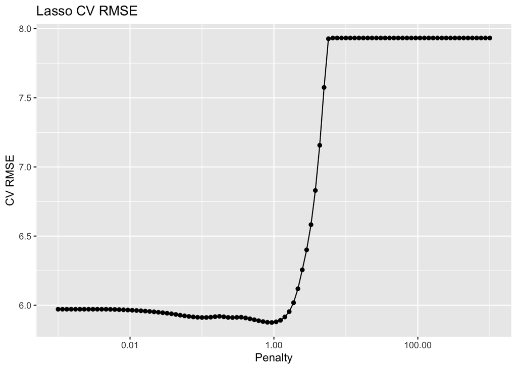

```r
# Visualize CV criterion
lasso_fit %>%
  collect_metrics() %>%
  print(width = Inf) %>%
  filter(.metric == "rmse") %>%
  ggplot(mapping = aes(x = penalty, y = mean)) +
  geom_line() +
  geom_point() +
  labs(title = "Lasso CV RMSE", x = "Penalty", y = "CV RMSE") +
  scale_x_log10(labels = scales::label_number())
```

```r
# Show the top 5 models (lambda values)
lasso_fit %>%
  show_best("rmse")
```

```
# A tibble: 5 × 7
  penalty .metric .estimator  mean     n std_err .config
    <dbl> <chr>   <chr>      <dbl> <int>   <dbl> <chr>
1   0.933 rmse    standard    5.88    10    1.21 Preprocessor1_Model050
2   0.811 rmse    standard    5.88    10    1.19 Preprocessor1_Model049
3   1.07  rmse    standard    5.88    10    1.22 Preprocessor1_Model051
4   0.705 rmse    standard    5.88    10    1.18 Preprocessor1_Model048
5   0.614 rmse    standard    5.89    10    1.17 Preprocessor1_Model047
```

```r
# Select the best model
best_lasso <-
  lasso_fit %>%
  select_best("rmse")
best_lasso
```

```
# A tibble: 1 × 2
  penalty .config
    <dbl> <chr>
1   0.933 Preprocessor1_Model050
```

```r
# Final workflow
final_wf <- lr_wf %>%
  finalize_workflow(best_lasso)
final_wf
```

```
══ Workflow ════════════════════════════════════════════════════════════════════
Preprocessor: Recipe
Model: linear_reg()

── Preprocessor ────────────────────────────────────────────────────────────────
3 Recipe Steps

• step_dummy()
• step_zv()
• step_normalize()

── Model ───────────────────────────────────────────────────────────────────────
Linear Regression Model Specification (regression)

Main Arguments:
  penalty = 0.93260334688322
  mixture = 1

Computational engine: glmnet
```

```r
# Fit the whole training set, then predict the test cases
final_fit <-
  final_wf %>%
  last_fit(data_split)
final_fit
```

```
# Resampling results
# Manual resampling
# A tibble: 1 × 6
  splits           id               .metrics .notes   .predictions .workflow
  <list>           <chr>            <list>   <list>   <list>       <list>
1 <split [478/28]> train/test split <tibble> <tibble> <tibble>     <workflow>
```

```r
# Test metrics
final_fit %>%
  collect_metrics()
```

```
# A tibble: 2 × 4
  .metric .estimator .estimate .config
  <chr>   <chr>          <dbl> <chr>
1 rmse    standard       2.99  Preprocessor1_Model1
2 rsq     standard       0.727 Preprocessor1_Model1
```

Model Ridge Regression

```r
ridge_mod <-
  linear_reg(penalty = tune(), mixture = 0) %>%
  set_engine("glmnet")
ridge_mod
```

```
Linear Regression Model Specification (regression)

Main Arguments:
  penalty = tune()
  mixture = 0

Computational engine: glmnet
```

Workflow

```r
lr_wf <-
  workflow() %>%
  add_model(ridge_mod) %>%
  add_recipe(norm_recipe)
lr_wf
```

```
══ Workflow ════════════════════════════════════════════════════════════════════
Preprocessor: Recipe
Model: linear_reg()

── Preprocessor ────────────────────────────────────────────────────────────────
3 Recipe Steps

• step_dummy()
• step_zv()
• step_normalize()

── Model ───────────────────────────────────────────────────────────────────────
Linear Regression Model Specification (regression)

Main Arguments:
  penalty = tune()
  mixture = 0

Computational engine: glmnet
```

Tuning grid

```r
lambda_grid <-
  grid_regular(penalty(range = c(-3,3), trans = log10_trans()), levels = 100)
lambda_grid
```

```
# A tibble: 100 × 1
   penalty
     <dbl>
 1 0.001
 2 0.00115
 3 0.00132
 4 0.00152
 5 0.00175
 6 0.00201
 7 0.00231
 8 0.00266
 9 0.00305
10 0.00351
# ℹ 90 more rows
```

Cross-validation (CV)

```r
# Set cross-validation partitions
set.seed(321)
folds <- vfold_cv(Boston_training, v = 10, strata = crim)
folds
```

```
#  10-fold cross-validation using stratification
# A tibble: 10 × 2
   splits           id
   <list>           <chr>
 1 <split [430/48]> Fold01
 2 <split [430/48]> Fold02
 3 <split [430/48]> Fold03
 4 <split [430/48]> Fold04
 5 <split [430/48]> Fold05
 6 <split [430/48]> Fold06
 7 <split [430/48]> Fold07
 8 <split [430/48]> Fold08
 9 <split [430/48]> Fold09
10 <split [432/46]> Fold10
```

```r
# Fit cross-validation
ridge_fit <-
  lr_wf %>%
  tune_grid(
    resamples = folds,
    grid = lambda_grid
  )
ridge_fit
```

```
# Tuning results
# 10-fold cross-validation using stratification
# A tibble: 10 × 4
   splits           id     .metrics           .notes
   <list>           <chr>  <list>             <list>
 1 <split [430/48]> Fold01 <tibble [200 × 5]> <tibble [0 × 3]>
 2 <split [430/48]> Fold02 <tibble [200 × 5]> <tibble [0 × 3]>
 3 <split [430/48]> Fold03 <tibble [200 × 5]> <tibble [0 × 3]>
 4 <split [430/48]> Fold04 <tibble [200 × 5]> <tibble [0 × 3]>
 5 <split [430/48]> Fold05 <tibble [200 × 5]> <tibble [0 × 3]>
 6 <split [430/48]> Fold06 <tibble [200 × 5]> <tibble [0 × 3]>
 7 <split [430/48]> Fold07 <tibble [200 × 5]> <tibble [0 × 3]>
 8 <split [430/48]> Fold08 <tibble [200 × 5]> <tibble [0 × 3]>
 9 <split [430/48]> Fold09 <tibble [200 × 5]> <tibble [0 × 3]>
10 <split [432/46]> Fold10 <tibble [200 × 5]> <tibble [0 × 3]>
```

```
# A tibble: 200 × 7
   penalty .metric .estimator  mean     n std_err .config
     <dbl> <chr>   <chr>      <dbl> <int>   <dbl> <chr>
 1 0.001   rmse    standard   6.07     10  0.988  Preprocessor1_Model001
 2 0.001   rsq     standard   0.546    10  0.0533 Preprocessor1_Model001
 3 0.00115 rmse    standard   6.07     10  0.988  Preprocessor1_Model002
 4 0.00115 rsq     standard   0.546    10  0.0533 Preprocessor1_Model002
 5 0.00132 rmse    standard   6.07     10  0.988  Preprocessor1_Model003
 6 0.00132 rsq     standard   0.546    10  0.0533 Preprocessor1_Model003
 7 0.00152 rmse    standard   6.07     10  0.988  Preprocessor1_Model004
 8 0.00152 rsq     standard   0.546    10  0.0533 Preprocessor1_Model004
 9 0.00175 rmse    standard   6.07     10  0.988  Preprocessor1_Model005
10 0.00175 rsq     standard   0.546    10  0.0533 Preprocessor1_Model005
# ℹ 190 more rows
```

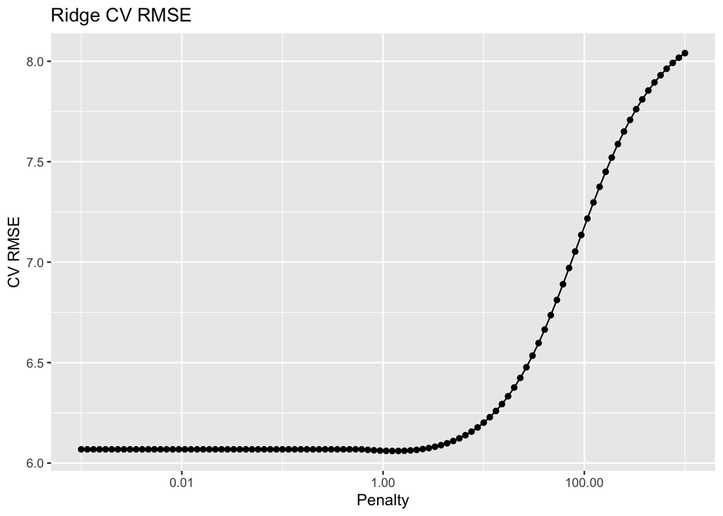

```r
# Visualize CV criterion
ridge_fit %>%
  collect_metrics() %>%
  print(width = Inf) %>%
  filter(.metric == "rmse") %>%
  ggplot(mapping = aes(x = penalty, y = mean)) +
  geom_line() +
  geom_point() +
  labs(title = "Ridge CV RMSE", x = "Penalty", y = "CV RMSE") +
  scale_x_log10(labels = scales::label_number())
```

```r
# Show the top 5 models (lambda values)
ridge_fit %>%
  show_best("rmse")
```

```
# A tibble: 5 × 7
  penalty .metric .estimator  mean     n std_err .config
    <dbl> <chr>   <chr>      <dbl> <int>   <dbl> <chr>
1   1.23  rmse    standard    6.06    10    1.01 Preprocessor1_Model052
2   1.42  rmse    standard    6.06    10    1.01 Preprocessor1_Model053
3   1.07  rmse    standard    6.06    10    1.00 Preprocessor1_Model051
4   1.63  rmse    standard    6.06    10    1.02 Preprocessor1_Model054
5   0.933 rmse    standard    6.06    10    1.00 Preprocessor1_Model050
```

```r
# Select the best model
best_ridge <-
  ridge_fit %>%
  select_best("rmse")
best_ridge
```

```
# A tibble: 1 × 2
  penalty .config
    <dbl> <chr>
1    1.23 Preprocessor1_Model052
```

```r
# Final workflow
final_wf <- lr_wf %>%
  finalize_workflow(best_ridge)
final_wf
```

```
══ Workflow ════════════════════════════════════════════════════════════════════
Preprocessor: Recipe
Model: linear_reg()

── Preprocessor ────────────────────────────────────────────────────────────────
3 Recipe Steps

• step_dummy()
• step_zv()
• step_normalize()

── Model ───────────────────────────────────────────────────────────────────────
Linear Regression Model Specification (regression)

Main Arguments:
  penalty = 1.23284673944207
  mixture = 0

Computational engine: glmnet
```

```r
# Fit the whole training set, then predict the test cases
final_fit <-
  final_wf %>%
  last_fit(data_split)
final_fit
```

```
# Resampling results
# Manual resampling
# A tibble: 1 × 6
  splits           id               .metrics .notes   .predictions .workflow
  <list>           <chr>            <list>   <list>   <list>       <list>
1 <split [478/28]> train/test split <tibble> <tibble> <tibble>     <workflow>
```

```r
# Test metrics
final_fit %>%
  collect_metrics()
```

```
# A tibble: 2 × 4
  .metric .estimator .estimate .config
  <chr>   <chr>          <dbl> <chr>
1 rmse    standard       3.05  Preprocessor1_Model1
2 rsq     standard       0.756 Preprocessor1_Model1
```

> 2. Propose a model (or set of models) that seem to perform well on this data set, and justify your answer. Make sure that you are evaluating model performance using validation set error, cross-validation, or some other reasonable alternative, as opposed to using training error.

**Answer:** From question a, we can know that the Lasso model has the lowest RMSE on test data set and cross-validation. Therefore, the Lasso model seems to perform well on this data set.

> 3. Does your chosen model involve all of the features in the data set? Why or why not?

**Answer:** No. It is not all features will be included, as the lasso penalization will perform feature selection.

## 9 Bonus question (20pts)

Consider a linear regression, fit by least squares to a set of training data $(x_1, y_1), \ldots, (x_N, y_N)$ drawn at random from a population. Let $\hat \beta$ be the least squares estimate. Suppose we have some test data $(\tilde{x}_1, \tilde{y}_1), \ldots, (\tilde{x}_M, \tilde{y}_M)$ drawn at random from the same population as the training data. If $R_{\text{train}}(\beta) = \frac{1}{N} \sum_{i=1}^N (y_i - \beta^T x_i)^2$ and $R_{\text{test}}(\beta) = \frac{1}{M} \sum_{i=1}^M (\tilde{y}_i - \beta^T \tilde{x}_i)^2$. Show that
$$\operatorname{E}[R_{\text{train}}(\hat{\beta})] < \operatorname{E}[R_{\text{test}}(\hat{\beta})].$$

**Answer:** For this problem, considering the number of training observations and test observations, we can divide it into two cases.

1. N < M, training observations are less than test observations.
   $$\begin{aligned}
   E[R_{\text{test}}(\hat{\beta})] &= E\left[ \frac{1}{M} \sum_{i=1}^M (\tilde{y}_i - \hat{\beta}^T \tilde{x}_i)^2 \right] \\
   &= \frac{1}{M} \sum_{i=1}^M E(\tilde{y}_i - \hat{\beta}^T \tilde{x}_i)^2 \\
   &\geq \frac{1}{M} \sum_{i=1}^M E(\tilde{y}_i - \beta'^T \tilde{x}_i)^2
   \end{aligned}$$
   where $\beta'$ is the ideal least squares estimate for the test data. We can see that the expected test error is the average of the expected test error for the least squares estimate for the test data.

The expected test error for the least squares estimate for the test data is the same as the expected training error for the least squares estimate for the test data.

Therefore, we can continue to write the expected test error as
$$\begin{aligned}
\frac{1}{M} \sum_{i=1}^M E(\tilde{y}_i - \beta'^T \tilde{x}_i)^2
&= \frac{1}{N} \sum_{i=1}^N E(\tilde{y}_i - \beta'^T \tilde{x}_i)^2 \\
&\geq \frac{1}{N} \sum_{i=1}^N E(y_i - \hat{\beta}^T x_i)^2 \\
&= \frac{1}{N} \sum_{i=1}^N E(y_i - \hat{\beta}^T x_i)^2 \\
&= E\left[ \frac{1}{N} \sum_{i=1}^N (y_i - \hat{\beta}^T x_i)^2 \right] \\
&= E[R_{\text{train}}(\hat{\beta})]
\end{aligned}$$
2. N > M, training observations are more than test observations. Similar proving process as case 1.
$$\begin{aligned}
E[R_{\text{train}}(\hat{\beta})] &= E\left[ \frac{1}{N} \sum_{i=1}^N (y_i - \hat{\beta}^T x_i)^2 \right] \\
&= \frac{1}{N} \sum_{i=1}^N E(y_i - \hat{\beta}^T x_i)^2 \\
&= E(y_1 - \hat{\beta}^T x_1)^2 \\
&= \frac{1}{M} \sum_{i=1}^M E(y_i - \hat{\beta}^T x_i)^2 \\
&\leq \frac{1}{M} \sum_{i=1}^M E(\tilde{y}_i - \beta'^T \tilde{x}_i)^2
\end{aligned}$$

Here $\beta'$ is still the ideal least squares estimate for the test data. We can see that the expected test error is the average of the expected test error for the least squares estimate for the test data. Then we have:

$$\begin{aligned}
\frac{1}{M} \sum_{i=1}^M E(\tilde{y}_i - \beta'^T \tilde{x}_i)^2
&\leq \frac{1}{M} \sum_{i=1}^M E(\tilde{y}_i - \hat{\beta}^T \tilde{x}_i)^2 \\
&= E\left[ \frac{1}{M} \sum_{i=1}^M (\tilde{y}_i - \hat{\beta}^T \tilde{x}_i)^2 \right] \\
&= E[R_{\text{test}}(\hat{\beta})
\end{aligned}$$
Then proved.